# Relatório 03 - Distribuições de Probabilidade

2022-05-04

## Introdução

Uma distribuição de probabilidade é um modelo matematico que relaciona um valor da variável em estudo com a sua probabilidade de ocorrência em um conjunto. Existem dois tipos de distribuição: a distribuição discreta e a distribuição contínua, que serão apresentadas a seguir.

## Distribuições Discretas de Probabilidade

Uma distribuição é dita discreta quando a variável aleatória em estudo é finita e contável. Definimos geralmente como dois possíveis resultados, o sucesso, *x=1* e o fracasso, *x=0*. Usualmente, o valor de interesse será a variável definida como *x=1*, por isso damos o nome de sucesso. No relatório apresentaremos as principais *Distribuições Discretas*, são elas: *Distribuição Binomial* e *Distribuição de Poisson*.

## Distribuição Binomial

Para o desenvolvimento de uma distribuição binomial é necessário que seu espaço amostral seja finito e definido para que assim sejam estabelecidos os dois parâmetros de saída possíveis, exclusivamente. Retornando à definição de sucesso e fracasso, para a distribuição binomial teremos:

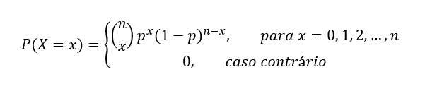

## Distribuição Binomial em R

```r
x <- 1:10
fx <- dbinom(x, 10, 0.5)
```

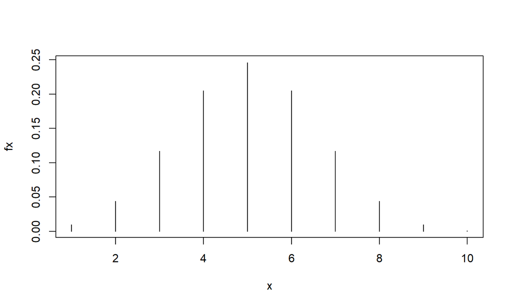

## Distribuição Binomial em R

```r
x <- 1:10
gx <- pbinom(x, 10, 0.5)
```

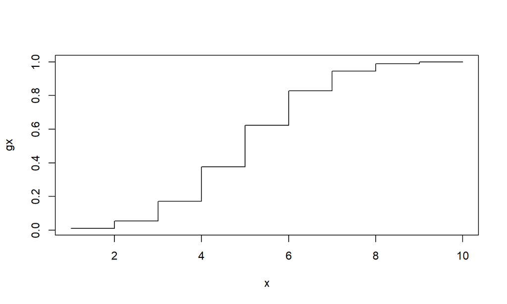

## Distribuição de Poisson

É a distribuição utilizada para definir eventos aleatórios ocorridos em um espaço de tempo definido:

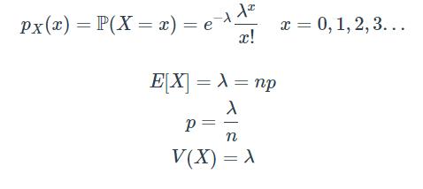

## Distribuição de Poisson em R

```
- dpois(x, lambda)
- ppois(x, lambda)
- qpois(x, lambda)
- rpois(x, lambda)
```

## Distribuições Contínuas de Probabilidade

Para uma distribuição contínua, temos um intervalo expresso de forma contínua, ou seja, a variável será expressa em uma escala infinita, como por exemplo: *0 < x < 1*, portanto, utilizando esse método, obteremos a probabilidade de que a variável esteja no intervalo definido.

## Distribuição Normal

É uma função densidade de probabilidade. É umarobabilidade absolutamente contínua parametrizada pela sua esperança matemática, com média e desvio padrão definidos.

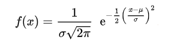